# Problem Set 4

Author

Sabrina Zhang

Published

November 20, 2026

### A Business Forecasting Horse Race: ARIMA vs. ETS

### 2.1a : Liquor sales and seasonal trends

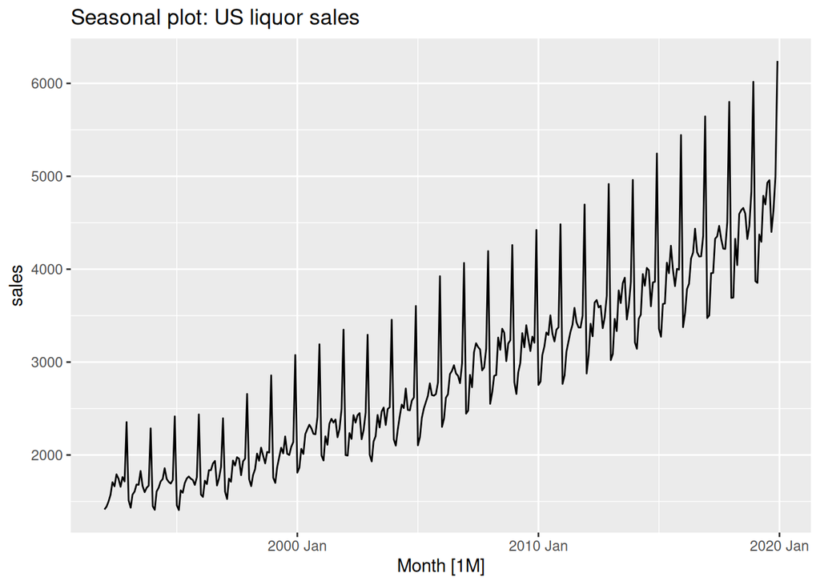

```r
sales_auto
```

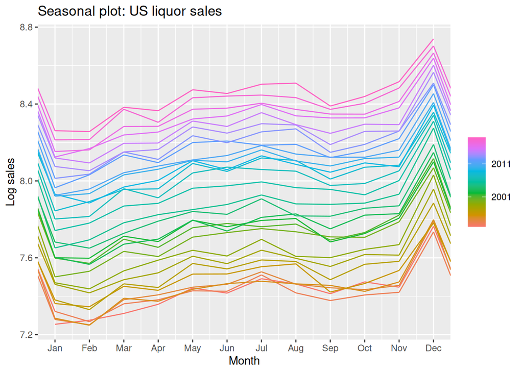

```r
log_sales_season
```

### **2.1b**

The seasonal trend of liquor sales remain steady throughout the year however we see a spike in December followed by a dip in January. The auto plot shows growth with the level of the series and suggesting that logging sales may take away that growth in level while capturing the month to month trend.

### **2.2a**

```r
liquor_fit_arima
```

```
# A mable: 1 x 1
                               arima
                             <model>
1 <ARIMA(1,0,2)(2,1,1)[12] w/ drift>
```

```r
liquor_fit_ets
```

```
# A mable: 1 x 1
           ets
       <model>
1 <ETS(A,A,A)>
```

The ARIMA Model choose the parameters (1,0,2)(2,1,1)[12] with drift. This means that we are lagging it for 2 periods in the seasonal component(P), taking the first difference (D), 1 period of forecast errors (Q) For the non seasonal model, we are lagging it once and incorporating 2 periods of forecast errors (q). For the ETS model, it chooses 3 additive components with alpha = 0.329 (level smoothing), beta = 0.007 (trend smoothing), and gamma = 0.0001 (seasonal smoothing).

The ETS model uses all additive terms for Error, Trend, and Seasonality (A,A,A). This means that the seasonal values are added to the model relative to the series units, the trend is represented by a change in fixed units over time, and the error term is added to the predictor.

### **2.2b**

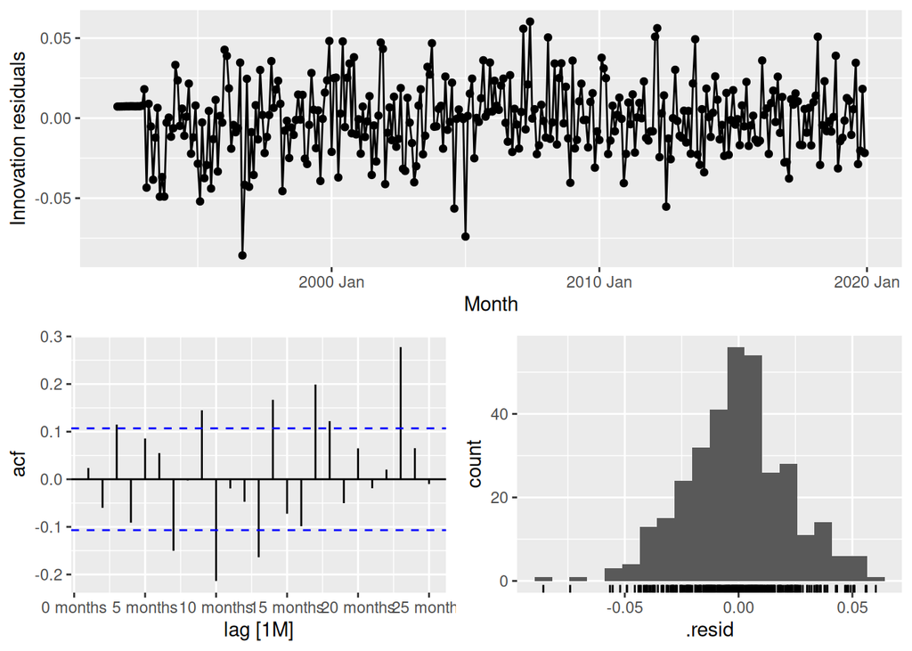

```r
liquor_fit |> select(arima) |> gg_tsresiduals()
```

```r
liquor_fit_ljung
```

```
# A tibble: 1 × 3
  .model lb_stat lb_pvalue
  <chr>    <dbl>     <dbl>
1 arima     120.         0
```

The residuals are clustered around 0 but there still seems to be lagging trends within the residuals that have not been captured by the model. The Ljung p value of 0 means we reject the null hypothesis that the residuals are white noise.

### 2.3. The Horse Race

The dates of the first forecast is January 2002 and the last forecast is December 2019.

```r
head(liquor_cv_fc,3)
```

```
# A fable: 3 x 5 [1M]
# Key:     .id, .model [3]
    .id .model    Month
  <int> <chr>     <mth>
1     1 snaive 2002 Jan
2     1 ets    2002 Jan
3     1 arima  2002 Jan
# ℹ 2 more variables: sales <dist>, .mean <dbl>
```

```r
tail(liquor_cv_fc,3)
```

```
# A fable: 3 x 5 [1M]
# Key:     .id, .model [3]
    .id .model    Month
  <int> <chr>     <mth>
1   216 snaive 2019 Dec
2   216 ets    2019 Dec
3   216 arima  2019 Dec
# ℹ 2 more variables: sales <dist>, .mean <dbl>
```

### **2.3b One Month Ahead Foreca**s**t**

For the one step ahead forecast, we get 216 forecast origins. Comparing the ARIMA vs MAE vs SNAIVE models, the ARIMA model forecasts the most accurately for both the RMSE and the MAE model.

```r
liquor_accuracy_table
```

| .model | RMSE | MAE |
| --- | --- | --- |
| arima | 81.43 | 65.65 |
| ets | 94.35 | 72.31 |
| snaive | 161.26 | 136.63 |

### 2.4. Are the Differences Significant? DM Test

```r
arima_ets
```

```
    Diebold-Mariano Test

data:  liquor_errs$arimaliquor_errs$ets
DM = -2.9062, Forecast horizon = 1, Loss function power = 2, p-value =
0.004042
alternative hypothesis: two.sided
```

```r
arima_snaive
```

```
    Diebold-Mariano Test

data:  liquor_errs$arimaliquor_errs$snaive
DM = -10.755, Forecast horizon = 1, Loss function power = 2, p-value <
2.2e-16
alternative hypothesis: two.sided
```

The DM statistic for the ARIMA vs ETS model is -2.9062 with a p-value of 0.004042

The DM statistic for the ARIMA vs SNAIVE model is -10.755 with a p-value of < 2.2e-16

This suggests that the ARIMA model shows significant evidence that it is better than both the ETS and the SNAIVE model. The DM statistic reports a negative value favoring the ARIMA model. As a liquor store chain, I would use the ARIMA model to forecast seasonal demand.

### 3. Forecast Combination

```r
liquor_combo_table
```

| .model | RMSE | MAE |
| --- | --- | --- |
| arima | 81.43 | 65.65 |
| combo | 85.19 | 66.77 |
| ets | 94.35 | 72.31 |
| snaive | 161.26 | 136.63 |

The combo model does significantly better than ETS or SNAIVE but the ARIMA model still is better by 3.8 in the RMSE and 1.1 the MAE.

### 3b. Correlation

```r
cor(liquor_errs$arima, liquor_errs$ets)
```

```
[1] 0.8782931
```

The correlation of the ARIMA and ETS model is 0.87. Generally when two models are correlated in terms of error, then combining the models results in producing similar results. Since the ARIMA and ETS model uses the same data, correlated error does not add more information to the model when averaged.

### 4. A Medium-Scale VAR vs. a BVAR

### 4.1c

Using 8 series from FRED, we now produce 120 forecasts for each variable starting in 1990-03-01 till 2019-12-01.

### 4.2. OLS VARs

```r
rmse_by_var(fc_var1)
```

```
      gdp      cons       inv       emp      infl    unrate       ffr      gs10
0.5130384 0.4598547 2.4927057 0.1956584 0.2084055 0.1988068 0.3902989 0.3610310
```

```r
rmse_by_var(fc_var4)
```

```
      gdp      cons       inv       emp      infl    unrate       ffr      gs10
0.5693241 0.5268484 2.5212629 0.2277561 0.2069608 0.2153966 0.4973504 0.3789663
```

Here, we can see that Var(1) forecast better than Var(4) for 7 out of 8 variables. Var(1) forecasts better than Var(4) because Var(4) contains several parameters that are lagged by 4 periods. Our original model already has several parameter to begin with, by lagging it by 4 we have 8*(8**4+1) = 264 parameters for VAR(4) and 8(8*1 + 1) = 72 parameters for VAR(1). With that many parameters, VAR(4) will have a larger error caused by overfitting of the model.

### 4.3. A BVAR

```r
var_results
```

| Variable | VAR(1) | VAR(4) | BVAR(4), lambda = 0.3 | BVAR(4), lambda = 0.05 |
| --- | --- | --- | --- | --- |
| gdp | 0.513 | 0.569 | 0.539 | 0.567 |
| cons | 0.460 | 0.527 | 0.486 | 0.495 |
| inv | 2.493 | 2.521 | 2.385 | 2.698 |
| emp | 0.196 | 0.228 | 0.211 | 0.315 |
| infl | 0.208 | 0.207 | 0.197 | 0.330 |
| unrate | 0.199 | 0.215 | 0.203 | 0.216 |
| ffr | 0.390 | 0.497 | 0.414 | 0.358 |
| gs10 | 0.361 | 0.379 | 0.359 | 0.362 |

The BVAR(4) does better than the VAR(4) for all of the variables. There are some variables that does better by a large margin. The VAR(4) model is a OLs model using 4 lag periods. The difference in the BVAR(4) also uses 4 lag periods however it applies shrinkage to prevent overfitting. This generalizes the model in a way that the VAR(4) fails to capture.

When lambda = 0.05, BVAR(4) does worse than BVAR(4) lambda = 0.3, however there are some variables where lambda = 0.05 does better than VAR(4). This suggests that the amount of shrinkage is important when considering how sensitive the variable is to the long term effects.

### 4.3c DM test

```r
dm_gdp
```

```
    Diebold-Mariano Test

data:  e_var4e_bvar
DM = 2.1366, Forecast horizon = 1, Loss function power = 2, p-value =
0.03468
alternative hypothesis: two.sided
```

The Diebold-Marino test for GDP growth for VAR(4) vs BVAR(4) with lambda = 0.3 has a p-value of 0.03. This tells us that at the 0.05 significance level, we reject the null hypothesis and say that there is statistically significant evidence that BVAR(4) is better than the VAR(4). This confirms my result in 4.3b that BVAR(4) does better however the p-value for significance level is not as strong on the 0.05 level.

```r
dm_inv
```

```
    Diebold-Mariano Test

data:  e_var4_inve_bvar_inv
DM = 1.6265, Forecast horizon = 1, Loss function power = 2, p-value =
0.1065
alternative hypothesis: two.sided
```

### 5. A Factor Model with FRED-MD

```r
head(fm)
```

```
# A tibble: 6 × 122
  date           RPI W875RX1 DPCERA3M086SBEA CMRMTSPLx RETAILx INDPRO IPFPNSS
  <date>       <dbl>   <dbl>           <dbl>     <dbl>   <dbl>  <dbl>   <dbl>
1 1960-03-01  0.188   0.0905          1.41      -2.80   -0.110 -0.902  -0.343
2 1960-04-01  0.346   0.361           1.53       0.985   2.59  -0.796   0.229
3 1960-05-01  0.241   0.243          -2.04      -3.15   -1.50  -0.114   0.569
4 1960-06-01  0.0764 -0.0235         -0.0250     0.855  -0.136 -1.27   -1.14
5 1960-07-01  0.179   0.191           0.206     -0.687  -1.01  -0.348  -0.576
6 1960-08-01 -0.160  -0.254          -0.0936    -0.127   0.341 -0.116  -0.231
# ℹ 114 more variables: IPFINAL <dbl>, IPCONGD <dbl>, IPDCONGD <dbl>,
#   IPNCONGD <dbl>, IPBUSEQ <dbl>, IPMAT <dbl>, IPDMAT <dbl>, IPNMAT <dbl>,
#   IPMANSICS <dbl>, IPB51222S <dbl>, IPFUELS <dbl>, CUMFNS <dbl>, HWI <dbl>,
#   HWIURATIO <dbl>, CLF16OV <dbl>, CE16OV <dbl>, UNRATE <dbl>, UEMPMEAN <dbl>,
#   UEMPLT5 <dbl>, UEMP5TO14 <dbl>, UEMP15OV <dbl>, UEMP15T26 <dbl>,
#   UEMP27OV <dbl>, CLAIMSx <dbl>, PAYEMS <dbl>, USGOOD <dbl>,
#   CES1021000001 <dbl>, USCONS <dbl>, MANEMP <dbl>, DMANEMP <dbl>, …
```

### 5.1c Transformations

```r
tcode[c("INDPRO", "PAYEMS", "CPIAUCSL", "FEDFUNDS")]
```

```
  INDPRO   PAYEMS CPIAUCSL FEDFUNDS
       5        5        6        2
```

Transformation:

INDPRO was transformed with 100 * d(log(x)) giving us the growth rate.

PAYEMS was transformed with 100 * d(log(x)) giving us the growth rate.

CIPAUCSL was transformed with 100 * d(d(log(x))) giving us the change in growth rate.

FEDFUNDS was transformed with d(x) giving us the first difference.

INDPRO represents the total industrial production index where the growth trends ith the level of the series. The FEDFUNDS is the interest rate set by the Feds and does not follow a trend. Instead we take the difference of each period to see how the interest rate changes over time.

### 5.2. Estimate the Factors: PCA

```r
PCA5
```

```
                            PC1      PC2      PC3      PC4      PC5
Standard deviation     4.258002 2.993839 2.923106 2.597224 2.295261
Proportion of Variance 0.149840 0.074070 0.070620 0.055750 0.043540
Cumulative Proportion  0.149840 0.223910 0.294530 0.350280 0.393820
```

The first three components of the PCA explain 0.29 of the variation.

### **5.2b.**

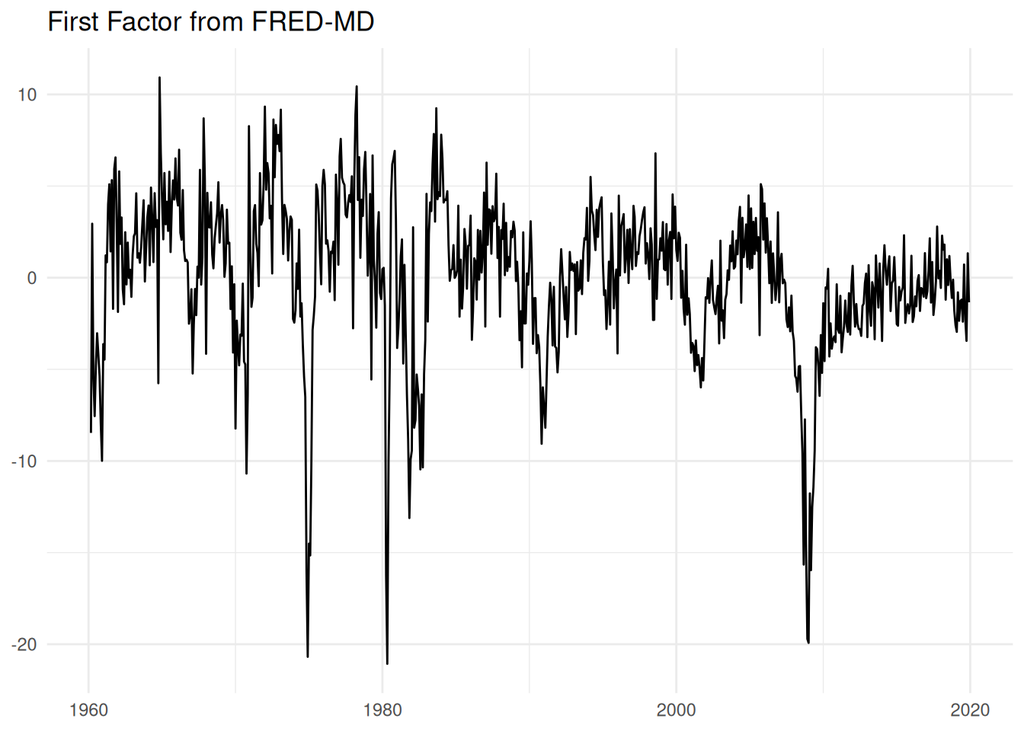

```r
tibble(date = fm$date, F1 = F1) |>
  ggplot(aes(date, F1)) +
  geom_line() +
  labs(title = "First Factor from FRED-MD", x = NULL, y = NULL) +
  theme_minimal()
```

```r
pc1
```

```
   PAYEMS IPMANSICS    USGOOD    INDPRO    MANEMP   IPFPNSS    CUMFNS   DMANEMP
0.8415788 0.8404473 0.8390159 0.8219976 0.8028499 0.7903078 0.7778686 0.7768615
```

```r
pc2
```

```
    CUSR0000SAC DNDGRG3M086SBEA   CUSR0000SA0L2        CPIAUCSL   CUSR0000SA0L5
      0.7468587       0.7391330       0.7279202       0.7198020       0.7020307
       CPITRNSL           PCEPI        CPIULFSL
      0.6806883       0.6795890       0.6570361
```

PCA 1 is looking at the variation explained within variables under the category of US industrial production or manufacturing output, including employment. Looking at the graph, we can see the overall trends in economic activity throughout time with the y axis fluctuating with the economic cycles.

PCA 2 looks at the variation among CPI in different sectors such as energy, food, housing, medical care, and transportation. This shows us the consumer price movement throughout time and how each variable can be explained by its strength in variation.

### 5.3. Replicate the Horse Race from Class

```r
c(RMSE_AR = sqrt(mean(e_ar^2)), RMSE_FA = sqrt(mean(e_fa^2)))
```

```
  RMSE_AR   RMSE_FA
0.6168431 0.5887272
```

Using the full data set to estimate the parameters then fitting it on the horse race model will include correlation in the data that are not present at the time training. This causes information leakage when modeling the training set into the testing set.

### 5.4. A Direct Forecast of Inflation

```r
direct_race("CPIAUCSL")
```

```
# A tibble: 1 × 7
  series   forecasts RMSE_AR RMSE_FA MAE_AR MAE_FA DM_pvalue
  <chr>        <int>   <dbl>   <dbl>  <dbl>  <dbl>     <dbl>
1 CPIAUCSL       349    2.11    1.89   1.58   1.35  0.000443
```

The percentage change was a 10.42% and 14.55% reduction in error for RMSE and MAE respectively. The DM value of 0.000443 tells us that there is statistically significant result that FA reduced the error compared to the AR model.

### Reflection

For this problem set, there is a recurring pattern where model complexity does not improve testing fit. We see this when comparing ARIMA vs. ETS vs. SNAIVE. While ARIMA beat ETS and SNAIVE, the ARIMA model alone still performed better than the combo model (ETS + ARIMA). In this case, ARIMA with parameters (1,0,2)(2,1,1)[12], being a slightly more complicated model, still beat the other models.

We see this again when comparing VAR(1) to VAR(4) and BVAR(4), lambda = 0.3, with BVAR(4), lambda = 0.05. The shrinkage parameters and the weights used in the data constrain variables within a model. Some variables do better, suggesting that additional lags combined with shrinkage may be beneficial. Overall, more complicated models do not necessarily improve fit when tested on out-of-sample data, however, producing the model also needs to account for case by case judgment in how the variables will be transformed.